# Pós-graduação em Ciências Veterinárias (IV/UFRRJ)

Modelo de Regressão Linear Múltipla - MRLM

Adriana Andrade Wagner Tassinari

2021

[figure not shown]

# Modelo de Regressão Linear Múltipla (MRLM)

Expressa a relação entre mais de duas variáveis quantitativas $X_1 , X_2, ..., X_k$ e $Y$ , de modo que se obtenha o valor esperado de $Y$ para cada valor de $X_i$, sendo $i = 1,2,...,k$, ou seja, $E(Y|x_1, x_2, ..., x_k)$.

Essa técnica possibilita estimar a magnitude dos efeitos de $X's$ em $Y$ a partir de uma função linear:

$$Y_i=\beta_{0}+\beta_{1}X_{1i}+\beta_{2}X_{2i}+...+\beta_{k}X_{ki}+\varepsilon_i \text{, sendo } i = 1,2,...,n$$

Sendo:

- $\beta_{0}$ - intercepto do modelo. Geralmente, não é interpretado. Representa o valor esperado de $Y$ quando $X = 0$;
- $\beta_{i}$ - representa o acréscimo esperado na variável resposta quando a variável explicativa é acrescida de uma unidade;
- $\varepsilon_i$ – erro aleatório. Esse termo representa os fatores não incluídos no modelo que, de alguma forma, causam variação em $Y$, ou seja, corresponde a variação em $Y$ que não é causada pelos $X_i$.

## Banco a ser utilizado

- Base de dados: daisy2.xlsx ([link](https://drive.google.com/file/d/1nwylCqb4_gFkch4sPBYHIajlCoQ0VQAz/view?usp=sharing))
- Conjunto de dados proveniente de um estudo tipo coorte a respeito das condições do manejo reprodutivo em rebanhos de bovinos leiteiros. O objetivo é avaliar o desempenho reprodutivo e a produção de leite desses animais.

## Preparando o banco de dados

- Abra o banco de dados:

```r
library(readxl)
daisy2 <- read_excel("~/Google Drive/UFRRJ/Modelos Regressão 2021/Bancos/daisy2.xlsx")

# Uma outra forma para importar os dados:

# daisy2 <- read_excel(file.choose())

# vamos apenas usar um subconjunto dos dados, pois apenas alguns rebanhos irão
# participar do estudo.
daisy2 <- daisy2[daisy2$h7 == 1, ]

# Visualizando o formato das vars no banco
str(daisy2)
```

```
tibble [1,976 × 19] (S3: tbl_df/tbl/data.frame)
 $ region    : num [1:1976] 1 1 1 1 1 1 1 1 1 1 ...
 $ herd      : num [1:1976] 1 1 1 1 1 1 1 1 1 1 ...
 $ cow       : num [1:1976] 1 2 3 4 5 6 7 8 9 10 ...
 $ study_lact: num [1:1976] 1 1 1 1 1 1 1 1 1 1 ...
 $ herd_size : num [1:1976] 294 294 294 294 294 294 294 294 294 294 ...
 $ mwp       : num [1:1976] 26 26 26 26 26 26 26 26 26 26 ...
 $ parity    : num [1:1976] 5 5 5 5 5 4 5 5 6 5 ...
 $ milk120   : num [1:1976] 3506 3691 4173 3727 3091 ...
 $ calv_dt   : num [1:1976] 13464 13526 13531 13556 13691 ...
 $ cf        : num [1:1976] 80 64 71 35 47 NA 46 44 62 NA ...
 $ fs        : num [1:1976] NA NA 0 1 0 NA NA 0 1 NA ...
 $ cc        : num [1:1976] NA NA 93 35 87 NA NA 143 62 NA ...
 $ wpc       : num [1:1976] NA NA 67 9 61 NA NA 117 36 NA ...
 $ spc       : num [1:1976] 6 3 2 1 2 NA 2 4 1 NA ...
 $ twin      : num [1:1976] 0 0 0 0 0 0 0 0 0 0 ...
 $ dyst      : num [1:1976] 0 0 0 0 0 0 0 0 0 0 ...
 $ rp        : num [1:1976] 0 0 0 0 0 1 0 0 0 0 ...
 $ vag_disch : num [1:1976] 0 0 0 0 0 0 0 0 0 0 ...
 $ h7        : num [1:1976] 1 1 1 1 1 1 1 1 1 1 ...
```

Ou siga as seguintes etapas no RStudio: *Environment –> Import Dataset –> From Excel…*

- Selecione as variáveis para compor o banco que será trabalhado
  - *cow* - Identificador do animal
  - *dyst* - Complicações no parto (Distocia fetal)
  - *milk120* - Litros de leite nos primeiros 120 dias de lactação
  - *mwp* - Período de espera até a concepção
  - *parity* - Número de lactação
  - *twin* - Nascimento duplo
  - *rp* - Retenção da placenta no parto
  - *vag_disch* - Corrimento vaginal observado

## Reduzindo a dimensão do banco

```r
# Seleção das variáveis que irão compor a base de dados

# Criando o objeto chamado banco e selecionando as vars que irão ficar no banco
myvars <- c("cow", "dyst", "milk120", "mwp", "parity", "twin", "rp", "vag_disch")
banco <- daisy2[myvars]

# Uma outra forma de selecionar as variáveis que irão compor o banco
# library(tidyverse) library(dplyr) banco <- daisy2 %>% select(cow,
# milk120,parity,mwp,dyst,twin, dyst, rp, vag_disch)
```

## Definindo o formato das vars do banco de dados

```r
# Colocando os labels nas variáveis categóricas

# Complicações no parto
banco$dyst <- factor(banco$dyst, labels = c("Nao", "Sim"))
banco$dyst <- relevel(banco$dyst, "Sim")

# Nascimento duplo
banco$twin <- factor(banco$twin, labels = c("Nao", "Sim"))
banco$twin <- relevel(banco$twin, "Sim")

# Retenção da placenta no parto
banco$rp <- factor(banco$rp, labels = c("Nao", "Sim"))
banco$rp <- relevel(banco$rp, "Sim")

# Corrimento vaginal observado
banco$vag_disch <- factor(banco$vag_disch, labels = c("Nao", "Sim"))
banco$vag_disch <- relevel(banco$vag_disch, "Sim")

# Categorizando a variável parity

banco$parity_cat <- cut((banco$parity), breaks = c(0, 1, 2, 4, Inf), labels = c("1 lactacao",
    "2 lactacoes", "3 a 4 lactacoes", "Mais de 4 lactacoes"))
```

## Verificando o banco

```r
str(banco)
```

[output not shown]

## Explorando o banco

```r
library(skimr)
skim(banco)
```

Data summary

| Name | banco |
| --- | --- |
| Number of rows | 1976 |
| Number of columns | 9 |
| _______________________ |  |
| Column type frequency: |  |
| factor | 5 |
| numeric | 4 |
| ________________________ |  |
| Group variables | None |

**Variable type: factor**

[output not shown]

**Variable type: numeric**

| skim_variable | n_missing | complete_rate | mean | sd | p0 | p25 | p50 | p75 | p100 | hist |
| --- | --- | --- | --- | --- | --- | --- | --- | --- | --- | --- |
| cow | 0 | 1.00 | 1413.86 | 1448.52 | 1.0 | 447.75 | 891.5 | 2279.0 | 5082.0 | ▇▂▂▁▂ |
| milk120 | 208 | 0.89 | 3225.31 | 703.36 | 1110.2 | 2742.42 | 3226.4 | 3693.3 | 5630.3 | ▁▅▇▃▁ |
| parity | 0 | 1.00 | 2.91 | 1.59 | 1.0 | 2.00 | 3.0 | 4.0 | 7.0 | ▇▃▂▂▁ |
| mwp | 0 | 1.00 | 35.84 | 10.52 | 21.0 | 26.00 | 40.0 | 44.0 | 50.0 | ▆▁▁▇▂ |

## Tratamento dos Valores Ausentes

Excluindo os valores ausentes da variável resposta $Y$. Uma outra maneira de tratar os valores ausentes é o uso de algum método de imputação.

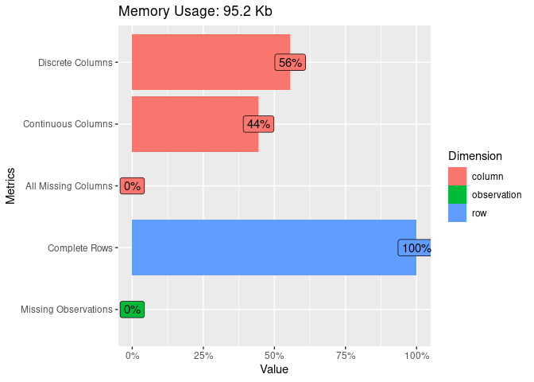

```r
# Excluindo os missings na var milk120
banco <- subset(banco, milk120 != is.na(milk120))

# Panorama geral do banco
library(DataExplorer)
plot_intro(banco)
```

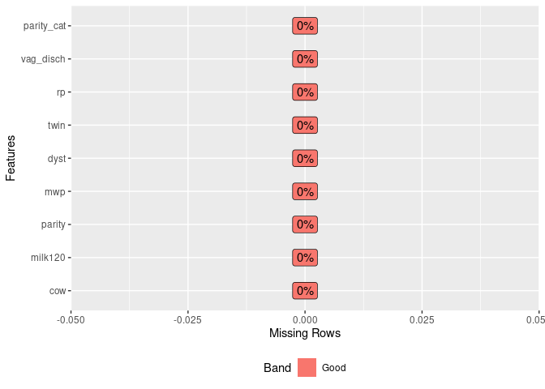

```r
plot_missing(banco)
```

## Ajuste do Modelo

- Vamos supor que estamos interessados em estudar a relação entre **a quantidade de leite produzida nos primeiros 120 dias de lactação** em relação algumas variáveis explicativas.

### Avaliação da correlação entre as variáveis quantitativas

```r
names(banco)
```

```
[1] "cow"        "milk120"    "parity"     "mwp"        "dyst"
[6] "twin"       "rp"         "vag_disch"  "parity_cat"
```

```r
# Matriz de correlação das vars quantitativas
cor(banco[c(2, 3, 4)])
```

```
          milk120      parity         mwp
milk120 1.0000000  0.38106613  0.17615411
parity  0.3810661  1.00000000 -0.02324586
mwp     0.1761541 -0.02324586  1.00000000
```

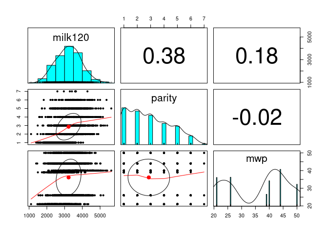

```r
# Forma gráfica
library(psych)
pairs.panels(banco[c(2, 3, 4)])
```

### Avaliação da correlação entre todos os tipos de variáveis

```r
library(polycor)
hetcor(banco[-1])  # retirando apenas a var cows
```

```
Two-Step Estimates

Correlations/Type of Correlation:
            milk120   parity      mwp       dyst       twin         rp
milk120           1  Pearson  Pearson Polyserial Polyserial Polyserial
parity       0.3815        1  Pearson Polyserial Polyserial Polyserial
mwp          0.1761 -0.02334        1 Polyserial Polyserial Polyserial
dyst         0.1217   0.2818  -0.2293          1 Polychoric Polychoric
twin        0.02753  -0.1599 -0.06679    0.03854          1 Polychoric
rp         0.003247  0.04088 -0.04668     0.1633     0.4203          1
vag_disch  -0.04817   0.1056 -0.09401     0.3593     0.4221     0.4675
parity_cat   0.4404   0.9945 -0.02867     0.3206    -0.2051    0.04774
            vag_disch parity_cat
milk120    Polyserial Polyserial
parity     Polyserial Polyserial
mwp        Polyserial Polyserial
dyst       Polychoric Polychoric
twin       Polychoric Polychoric
rp         Polychoric Polychoric
vag_disch           1 Polychoric
parity_cat     0.1159          1

Standard Errors:
           milk120    parity     mwp    dyst    twin      rp vag_disch
milk120
parity     0.02034
mwp        0.02305   0.02378
dyst       0.04814   0.04804 0.04934
twin       0.06806   0.06112 0.06639  0.1245
rp         0.04064   0.04127 0.04085  0.0734 0.07855
vag_disch  0.04747   0.04923 0.05062 0.07285 0.08744 0.05811
parity_cat 0.01936 0.0005397 0.02547 0.04708  0.0675 0.04363    0.0512

n = 1768

P-values for Tests of Bivariate Normality:
              milk120     parity                   mwp    dyst   twin      rp
milk120
parity      6.349e-43
mwp        4.956e-235 1.548e-241
dyst           0.6273  5.082e-16            5.649e-233
twin         0.002018  8.315e-14 9.45199999999999e-233    <NA>
rp             0.8949  2.528e-13 8.71199999999999e-233    <NA>   <NA>
vag_disch      0.5264  3.142e-13            2.118e-242    <NA>   <NA>    <NA>
parity_cat  2.923e-30        NaN            1.735e-232 0.01628 0.2335 0.02146
           vag_disch
milk120
parity
mwp
dyst
twin
rp
vag_disch
parity_cat    0.7037
```

## Modelos bivariados com todas as variáveis selecionadas (supondo $\alpha = 20\%$)

```r
m1 <- lm(milk120 ~ parity, banco)
m2 <- lm(milk120 ~ mwp, banco)
m3 <- lm(milk120 ~ dyst, banco)
m4 <- lm(milk120 ~ twin, banco)
m5 <- lm(milk120 ~ rp, banco)
m6 <- lm(milk120 ~ vag_disch, banco)
m7 <- lm(milk120 ~ parity_cat, banco)

summary(m1)
```

```
Call:
lm(formula = milk120 ~ parity, data = banco)

Residuals:
     Min       1Q   Median       3Q      Max
-1966.89  -433.40   -14.28   424.68  2151.20

Coefficients:
            Estimate Std. Error t value Pr(>|t|)
(Intercept) 2733.862     32.317   84.60   <2e-16 ***
parity       171.614      9.908   17.32   <2e-16 ***
---
Signif. codes:  0 '***' 0.001 '**' 0.01 '*' 0.05 '.' 0.1 ' ' 1

Residual standard error: 650.5 on 1766 degrees of freedom
Multiple R-squared:  0.1452,    Adjusted R-squared:  0.1447
F-statistic:   300 on 1 and 1766 DF,  p-value: < 2.2e-16
```

```r
summary(m2)
```

```
Call:
lm(formula = milk120 ~ mwp, data = banco)

Residuals:
     Min       1Q   Median       3Q      Max
-1934.38  -495.33     1.67   458.87  2358.67

Coefficients:
            Estimate Std. Error t value Pr(>|t|)
(Intercept) 2793.634     59.718   46.78  < 2e-16 ***
mwp           11.950      1.589    7.52 8.65e-14 ***
---
Signif. codes:  0 '***' 0.001 '**' 0.01 '*' 0.05 '.' 0.1 ' ' 1

Residual standard error: 692.6 on 1766 degrees of freedom
Multiple R-squared:  0.03103,   Adjusted R-squared:  0.03048
F-statistic: 56.55 on 1 and 1766 DF,  p-value: 8.651e-14
```

```r
summary(m3)
```

```
Call:
lm(formula = milk120 ~ dyst, data = banco)

Residuals:
     Min       1Q   Median       3Q      Max
-2125.46  -480.84     9.09   465.37  2394.64

Coefficients:
            Estimate Std. Error t value Pr(>|t|)
(Intercept)  3063.10      68.22  44.900   <2e-16 ***
dystNao       172.56      70.36   2.452   0.0143 *
---
Signif. codes:  0 '***' 0.001 '**' 0.01 '*' 0.05 '.' 0.1 ' ' 1

Residual standard error: 702.4 on 1766 degrees of freedom
Multiple R-squared:  0.003394,  Adjusted R-squared:  0.00283
F-statistic: 6.014 on 1 and 1766 DF,  p-value: 0.01429
```

```r
summary(m4)
```

```
Call:
lm(formula = milk120 ~ twin, data = banco)

Residuals:
     Min       1Q   Median       3Q      Max
-2116.12  -483.89     3.93   466.98  2403.98

Coefficients:
            Estimate Std. Error t value Pr(>|t|)
(Intercept)  3184.00     108.56  29.330   <2e-16 ***
twinNao        42.32     109.87   0.385      0.7
---
Signif. codes:  0 '***' 0.001 '**' 0.01 '*' 0.05 '.' 0.1 ' ' 1

Residual standard error: 703.5 on 1766 degrees of freedom
Multiple R-squared:  8.401e-05, Adjusted R-squared:  -0.0004822
F-statistic: 0.1484 on 1 and 1766 DF,  p-value: 0.7001
```

```r
summary(m5)
```

```
Call:
lm(formula = milk120 ~ rp, data = banco)

Residuals:
     Min       1Q   Median       3Q      Max
-2111.19  -483.33     2.28   467.54  2404.54

Coefficients:
            Estimate Std. Error t value Pr(>|t|)
(Intercept) 3221.392     52.295  61.600   <2e-16 ***
rpNao          4.366     55.197   0.079    0.937
---
Signif. codes:  0 '***' 0.001 '**' 0.01 '*' 0.05 '.' 0.1 ' ' 1

Residual standard error: 703.6 on 1766 degrees of freedom
Multiple R-squared:  3.543e-06, Adjusted R-squared:  -0.0005627
F-statistic: 0.006257 on 1 and 1766 DF,  p-value: 0.937
```

```r
summary(m6)
```

```
Call:
lm(formula = milk120 ~ vag_disch, data = banco)

Residuals:
     Min       1Q   Median       3Q      Max
-2110.89  -483.84     2.09   468.03  2409.21

Coefficients:
             Estimate Std. Error t value Pr(>|t|)
(Intercept)   3294.92      69.99  47.079   <2e-16 ***
vag_dischNao   -73.83      72.08  -1.024    0.306
---
Signif. codes:  0 '***' 0.001 '**' 0.01 '*' 0.05 '.' 0.1 ' ' 1

Residual standard error: 703.4 on 1766 degrees of freedom
Multiple R-squared:  0.0005938, Adjusted R-squared:  2.785e-05
F-statistic: 1.049 on 1 and 1766 DF,  p-value: 0.3058
```

```r
summary(m7)
```

[output not shown]

Podemos interpretar os modelos bivariados cujos preditores foram significativas dessa forma:

**m1)** O coeficiente estimado $\beta_1 = 171,60 [IC 95\%: 152,18; 191,05]$ indica que a cada parto, observa-se um aumento de aproximadamente 172 litros na produção de leite.

**m2)** O coeficiente estimado $\beta_1 = 11.95 [IC 95\%: 8,83; 15,07]$ indica que para cada dia entre o periodo de espera ate a concepçao, observa-se um aumento de aproximadamente 12 litros na produção de leite.

**m3)** O coeficiente estimado $\beta_1 = 172.56 [IC 95\%: 34,56; 310,56]$ indica que o grupo dos animais que não tiveram complicações no parto, apresenta uma produçaõ de leite aumentada em aproximadamente 173 litros de leite.

**m7)** Esse modelo indica um gradiente em relação ao grupo que apresentou uma lactação na vida, indicando um aumento na produção do leite a medida que o número de lactações aumenta

## Analisando as variáveis *dyst* e *parity_cat* (vars dummies)

**Grupos referentes as complicações no parto (*dyst*)**

```r
# Teste t
t.test(milk120 ~ dyst, banco)
```

```
    Welch Two Sample t-test

data:  milk120 by dyst
t = -2.8296, df = 124.31, p-value = 0.005437
alternative hypothesis: true difference in means between group Sim and group Nao is not equal to 0
95 percent confidence interval:
 -293.25762  -51.85563
sample estimates:
mean in group Sim mean in group Nao
         3063.100          3235.657
```

Através do teste t, observamos que a produção do leite apresenta uma diferença estatísticamente significativa entre os animais que tiveram complicações no parto e os animais que não tiveram complicações no parto ($t = -2,8296$; $p-valor = 0,0054$)

```r
# Anova
obj.anova <- aov(milk120 ~ parity_cat, banco)
summary(obj.anova)
```

```
              Df    Sum Sq  Mean Sq F value Pr(>F)
parity_cat     3 210236002 70078667   186.2 <2e-16 ***
Residuals   1764 663935938   376381
---
Signif. codes:  0 '***' 0.001 '**' 0.01 '*' 0.05 '.' 0.1 ' ' 1
```

```r
# Teste de Tukey (Pós-teste)
TukeyHSD(obj.anova)
```

```
  Tukey multiple comparisons of means
    95% family-wise confidence level

Fit: aov(formula = milk120 ~ parity_cat, data = banco)

$parity_cat
                                         diff        lwr      upr     p adj
2 lactacoes-1 lactacao              715.29914 606.120794 824.4775 0.0000000
3 a 4 lactacoes-1 lactacao          811.40464 712.256796 910.5525 0.0000000
Mais de 4 lactacoes-1 lactacao      848.67989 733.782707 963.5771 0.0000000
3 a 4 lactacoes-2 lactacoes          96.10550  -5.804768 198.0158 0.0727925
Mais de 4 lactacoes-2 lactacoes     133.38076  16.091491 250.6700 0.0183484
Mais de 4 lactacoes-3 a 4 lactacoes  37.27525 -70.739354 145.2899 0.8114221
```

Através da ANOVA, observamos que a produção do leite apresenta uma diferença estatísticamente significativa entre os grupos de animais com distintos quantidade de lactação ($F= 186,20$; $p-valor < 0,001$)

## Ajustando um MRLM com as variáveis que foram significativas a partir dos MRLS.

```r
m_manual <- lm(milk120 ~ parity + dyst, banco)
summary(m_manual)
```

```
Call:
lm(formula = milk120 ~ parity + dyst, data = banco)

Residuals:
     Min       1Q   Median       3Q      Max
-1968.87  -434.71   -16.22   423.21  2149.73

Coefficients:
            Estimate Std. Error t value Pr(>|t|)
(Intercept) 2711.205     66.455   40.80   <2e-16 ***
parity       171.105      9.996   17.12   <2e-16 ***
dystNao       25.653     65.742    0.39    0.696
---
Signif. codes:  0 '***' 0.001 '**' 0.01 '*' 0.05 '.' 0.1 ' ' 1

Residual standard error: 650.6 on 1765 degrees of freedom
Multiple R-squared:  0.1453,    Adjusted R-squared:  0.1443
F-statistic:   150 on 2 and 1765 DF,  p-value: < 2.2e-16
```

Apesar da variável *dyst* sozinha ter sido significativa para para explicar a variabilidade da produção do leite, quando ela é ajustada junto com a variável *parity*, ela acaba perdendo a significância pois a variável *parity* está conseguindo explicar sozinha a produção de leite.

**Métricas de ajuste**

```r
library(performance)
model_performance(m_manual)
```

```
# Indices of model performance

AIC       |       BIC |    R2 | R2 (adj.) |    RMSE |   Sigma
-------------------------------------------------------------
27928.385 | 27950.296 | 0.145 |     0.144 | 650.082 | 650.634
```

De qualquer forma o $R^2$ está muito baixo e o $RMSE$ está muito alto.

## Ajustando de forma automática um MRLM.

```r
# Modelo com todas as variáveis
modelo.cheio <- lm(milk120 ~ parity + mwp + dyst + twin + rp + vag_disch, data = banco)

# Modelo sem variáveis independentes
modelo.vazio <- lm(milk120 ~ 1, data = banco)

library(MASS)
# Modelo ajustado via Backward
m_backward <- stepAIC(modelo.cheio, scope = list(upper = modelo.cheio, lower = modelo.vazio),
    direction = "backward")
```

```
Start:  AIC=22835.88
milk120 ~ parity + mwp + dyst + twin + rp + vag_disch

            Df Sum of Sq       RSS   AIC
- rp         1       245 713654287 22834
<none>                   713654042 22836
- dyst       1    913674 714567717 22836
- twin       1   1583585 715237627 22838
- vag_disch  1   1727651 715381693 22838
- mwp        1  30392802 744046844 22908
- parity     1 127307453 840961495 23124

Step:  AIC=22833.88
milk120 ~ parity + mwp + dyst + twin + vag_disch

            Df Sum of Sq       RSS   AIC
<none>                   713654287 22834
- dyst       1    913539 714567826 22834
- twin       1   1601804 715256091 22836
- vag_disch  1   1795762 715450050 22836
- mwp        1  30400616 744054903 22906
- parity     1 127340283 840994571 23122
```

```r
# Modelo ajustado via Forward
m_forward <- stepAIC(modelo.cheio, scope = list(upper = modelo.cheio, lower = modelo.vazio),
    direction = "forward")
```

```
Start:  AIC=22835.88
milk120 ~ parity + mwp + dyst + twin + rp + vag_disch
```

```r
# Modelo ajustado via ambos os métodos
m_both <- stepAIC(modelo.cheio, scope = list(upper = modelo.cheio, lower = modelo.vazio),
    direction = "both")
```

```
Start:  AIC=22835.88
milk120 ~ parity + mwp + dyst + twin + rp + vag_disch

            Df Sum of Sq       RSS   AIC
- rp         1       245 713654287 22834
<none>                   713654042 22836
- dyst       1    913674 714567717 22836
- twin       1   1583585 715237627 22838
- vag_disch  1   1727651 715381693 22838
- mwp        1  30392802 744046844 22908
- parity     1 127307453 840961495 23124

Step:  AIC=22833.88
milk120 ~ parity + mwp + dyst + twin + vag_disch

            Df Sum of Sq       RSS   AIC
<none>                   713654287 22834
- dyst       1    913539 714567826 22834
- twin       1   1601804 715256091 22836
+ rp         1       245 713654042 22836
- vag_disch  1   1795762 715450050 22836
- mwp        1  30400616 744054903 22906
- parity     1 127340283 840994571 23122
```

```r
summary(m_forward)
```

```
Call:
lm(formula = milk120 ~ parity + mwp + dyst + twin + rp + vag_disch,
    data = banco)

Residuals:
     Min       1Q   Median       3Q      Max
-1984.58  -428.46   -11.87   412.70  2099.04

Coefficients:
             Estimate Std. Error t value Pr(>|t|)
(Intercept)  2112.935    140.859  15.000   <2e-16 ***
parity        173.882      9.811  17.724   <2e-16 ***
mwp            12.726      1.470   8.660   <2e-16 ***
dystNao        97.874     65.183   1.502   0.1334
twinNao       200.364    101.359   1.977   0.0482 *
rpNao          -1.265     51.442  -0.025   0.9804
vag_dischNao -139.753     67.686  -2.065   0.0391 *
---
Signif. codes:  0 '***' 0.001 '**' 0.01 '*' 0.05 '.' 0.1 ' ' 1

Residual standard error: 636.6 on 1761 degrees of freedom
Multiple R-squared:  0.1836,    Adjusted R-squared:  0.1808
F-statistic: 66.02 on 6 and 1761 DF,  p-value: < 2.2e-16
```

```r
summary(m_backward)
```

```
Call:
lm(formula = milk120 ~ parity + mwp + dyst + twin + vag_disch,
    data = banco)

Residuals:
     Min       1Q   Median       3Q      Max
-1984.67  -428.56   -11.97   412.59  2098.94

Coefficients:
             Estimate Std. Error t value Pr(>|t|)
(Intercept)  2112.415    139.221  15.173   <2e-16 ***
parity        173.878      9.806  17.731   <2e-16 ***
mwp            12.727      1.469   8.664   <2e-16 ***
dystNao        97.830     65.141   1.502   0.1333
twinNao       200.066    100.602   1.989   0.0469 *
vag_dischNao -140.059     66.516  -2.106   0.0354 *
---
Signif. codes:  0 '***' 0.001 '**' 0.01 '*' 0.05 '.' 0.1 ' ' 1

Residual standard error: 636.4 on 1762 degrees of freedom
Multiple R-squared:  0.1836,    Adjusted R-squared:  0.1813
F-statistic: 79.26 on 5 and 1762 DF,  p-value: < 2.2e-16
```

```r
summary(m_both)
```

```
Call:
lm(formula = milk120 ~ parity + mwp + dyst + twin + vag_disch,
    data = banco)

Residuals:
     Min       1Q   Median       3Q      Max
-1984.67  -428.56   -11.97   412.59  2098.94

Coefficients:
             Estimate Std. Error t value Pr(>|t|)
(Intercept)  2112.415    139.221  15.173   <2e-16 ***
parity        173.878      9.806  17.731   <2e-16 ***
mwp            12.727      1.469   8.664   <2e-16 ***
dystNao        97.830     65.141   1.502   0.1333
twinNao       200.066    100.602   1.989   0.0469 *
vag_dischNao -140.059     66.516  -2.106   0.0354 *
---
Signif. codes:  0 '***' 0.001 '**' 0.01 '*' 0.05 '.' 0.1 ' ' 1

Residual standard error: 636.4 on 1762 degrees of freedom
Multiple R-squared:  0.1836,    Adjusted R-squared:  0.1813
F-statistic: 79.26 on 5 and 1762 DF,  p-value: < 2.2e-16
```

- Utilizando o médo de seleção setpAIC pelos três algorítmos, os modelos ajustado através dos métodos *backward* e *both*, são os mesmos. Já o modelo ajustado pelo método *forward* é diferente, pois a variável *rp* entra no modelo.
- Apesar das variaveis *dyst* e *rp* (esta no caso específico par ao modelo ajustado via o método *forward*) continuarem sendo não significativas, elas permanecem no modelo por conta do princípio da parcimônia.
- As variáveis *twin* e *vag_disch* que não foram significativas quando ajustadas isoladamente com a produção do leite, mas agora ela passaram a ser significativas.

#### Comparando os modelos *backward* e *forward*

**Métricas de ajuste**

```r
model_performance(m_forward)
```

```
# Indices of model performance

AIC       |       BIC |    R2 | R2 (adj.) |    RMSE |   Sigma
-------------------------------------------------------------
27855.249 | 27899.070 | 0.184 |     0.181 | 635.335 | 636.596
```

```r
model_performance(m_backward)
```

```
# Indices of model performance

AIC       |       BIC |    R2 | R2 (adj.) |    RMSE |   Sigma
-------------------------------------------------------------
27853.250 | 27891.593 | 0.184 |     0.181 | 635.335 | 636.416
```

**Comparando os modelos via ANOVA**

```r
anova(m_forward, m_backward)
```

```
Analysis of Variance Table

Model 1: milk120 ~ parity + mwp + dyst + twin + rp + vag_disch
Model 2: milk120 ~ parity + mwp + dyst + twin + vag_disch
  Res.Df       RSS Df Sum of Sq     F Pr(>F)
1   1761 713654042
2   1762 713654287 -1    -245.1 6e-04 0.9804
```

- Segundo as métricas de ajuste, ambos os modelos são muito parecidos em performace.
- $R^2_{ajustado}$ e o $RMSE$ são iguais
- Inclusive pelo teste $F$ da ANOVa para comparação entre os modelos, sugere que não existem evidências dizer que os modelos são estatísticamente diferentes, ou seja, não apresentam uma diferença significativa quanto ao critério de parcimonia.
- Somente notamos uma diferença bem sutil no $AIC$ e o $BIC$, por isso vamos escolher o modelo ajustado via o algorítmo *backward*, até por que ele não inclui a variável *rp*, que não foi significativa no modelo.

#### Comparando o modelo “manual” com o ajustado via stepAIC

**Métricas de ajuste**

```r
model_performance(m_manual)
```

```
# Indices of model performance

AIC       |       BIC |    R2 | R2 (adj.) |    RMSE |   Sigma
-------------------------------------------------------------
27928.385 | 27950.296 | 0.145 |     0.144 | 650.082 | 650.634
```

```r
model_performance(m_backward)
```

```
# Indices of model performance

AIC       |       BIC |    R2 | R2 (adj.) |    RMSE |   Sigma
-------------------------------------------------------------
27853.250 | 27891.593 | 0.184 |     0.181 | 635.335 | 636.416
```

- O $R^2$ aumenta cerca de $4\%$.
- O $AIC$, $BIC$ e o $RMSE$ diminuem.
- O desvio padrão dos resíduos ($Sigma$) também diminui.

**Comparando os modelos via ANOVA**

```r
anova(m_manual, m_backward)
```

```
Analysis of Variance Table

Model 1: milk120 ~ parity + dyst
Model 2: milk120 ~ parity + mwp + dyst + twin + vag_disch
  Res.Df       RSS Df Sum of Sq      F    Pr(>F)
1   1765 747167756
2   1762 713654287  3  33513469 27.581 < 2.2e-16 ***
---
Signif. codes:  0 '***' 0.001 '**' 0.01 '*' 0.05 '.' 0.1 ' ' 1
```

- Aparentemente, existem evidências de que que o modelo ajustado via stepAIC é o modelo mais adequado ($F= 27,58$; $p-valor < 0.001$).

### Diagnóstico de ajuste do modelo mais adequado

**i) Normalidade dos resíduos**

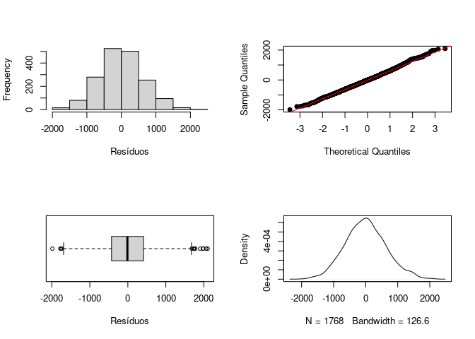

```r
# Analise gráfica
par(mfrow = c(2, 2))
hist(m_backward$residuals, xlab = "Resíduos", main = "")  # Histograma

qqnorm(m_backward$residuals, pch = 19, main = "")  #QQNorm dos resíduos
qqline(m_backward$residuals, col = "red")

boxplot(m_backward$residuals, xlab = "Resíduos", horizontal = T)  # Boxplot

plot(density(m_backward$residuals), main = "")  # Plot density
```

```r
# Teste de Shapiro-Wilk
shapiro.test(m_backward$residuals)
```

```
    Shapiro-Wilk normality test

data:  m_backward$residuals
W = 0.99803, p-value = 0.03141
```

```r
# Teste de Kolmogorov-Smirnov
ks.test(m_backward$residuals, "pnorm", mean = mean(m_backward$residuals), sd = sd(m_backward$residuals))
```

```
    One-sample Kolmogorov-Smirnov test

data:  m_backward$residuals
D = 0.020425, p-value = 0.452
alternative hypothesis: two-sided
```

**ii) Múlticolinearidade**

```r
library(car)
vif(m_backward)
```

```
   parity       mwp      dyst      twin vag_disch
 1.023326  1.012081  1.043939  1.024573  1.040271
```

- Não foi observados colinearidade em nenhuma variável ($VIF's < 5$).

**iii) Homocedasticidade dos Resíduos**

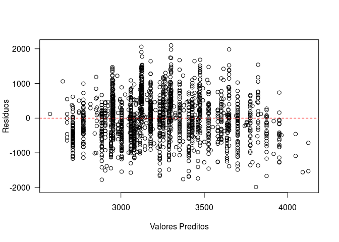

```r
## Grafico do predito x residuo
plot(m_backward$fitted.values, m_backward$residuals, xlab = "Valores Preditos", ylab = "Resíduos",
    main = "", las = 1)
abline(h = 0, lwd = 1, lty = 2, col = "red")
```

```r
# Teste de Breusch-Pagan
library(lmtest)
bptest(m_backward)
```

```
    studentized Breusch-Pagan test

data:  m_backward
BP = 25.993, df = 5, p-value = 8.95e-05
```

- Através do teste *Breusch-Pagan*, não podemos dizer que os resíduos apresntam homocedasticidade ($BP = 25,99$ $p-value < 0,001$.

**Checagem do modelo de forma geral**

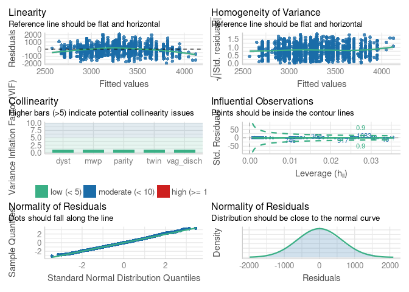

```r
check_model(m_backward)
```

## Transformação de variáveis

- Tendo constatado a violação de alguma suposição na etapa de Análise de Resíduos, existe a possibilidade de aplicar uma transformação na variável resposta $Y$ e/ou em $X$.

### Algumas transformações em $Y$

- $ln(Y)$: para estabilizar a variância quando esta tende a crescer a medida que $Y$ cresce
- $\sqrt{Y}$: para estabilizar a variância quando esta é proporcional à média dos $Y$’s cresce
- $\dfrac{1}{Y}$: para estabilizar a variância, minimizando o efeito de valores muito altos de $Y$
- $Y^2$: para estabilizar a variância quando esta tende a decrescer com a média de $Y$’s
- etc …

### Transformações de Box-Cox

- Muitas vezes é difícil determinar, através de gráficos, qual a melhor transformação a ser feita.
- O procedimento de Box-Cox identifica automaticamente uma trasformação:

$$Y' = Y^{\lambda}$$

em que $\lambda$ é um parâmetro a ser determinado a partir dos dados.

$$\begin{equation}
Y^{\lambda}=\begin{cases}
\dfrac{Y^{\lambda} - 1}{\lambda}, & \text{se $\lambda \neq 0$}.\\
ln(Y), & \text{se $\lambda = 0$}.
\end{cases}
\end{equation}$$

- O procedimento de Box-Cox utiliza o método de máxima verossimilhança para estimar $\lambda$.

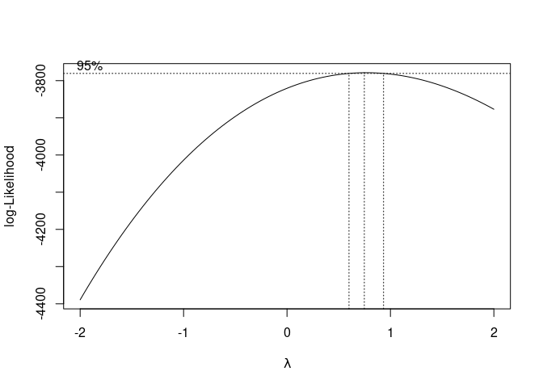

```r
library(MASS)

# Transformação boxcox
boxcox(m_backward)

# Encontrando o lambda
bc <- boxcox(m_backward)
```

```r
lambda <- bc$x[which.max(bc$y)]
lambda
```

```
[1] 0.7474747
```

- Aplicando a Transformação de Box-Cox obtemos um valor de 0.7474747` que maximiza a log-verossimilhança para a transformação realizada.

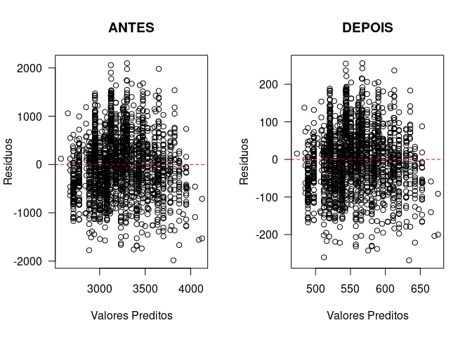

```r
# Aplicação da transformação boxcox em Y
banco$milk120t <- (banco$milk120^(lambda) - 1)/lambda

# Ajuste do modelo com variável transformada
m_backward2 <- lm(milk120t ~ parity + mwp + dyst + twin + vag_disch, data = banco)


# Comparação do gráfico predito vs resíduos antes e depois da transformação
par(mfrow = c(1, 2))
plot(m_backward$fitted.values, m_backward$residuals, xlab = "Valores Preditos", ylab = "Resíduos",
    main = "ANTES", las = 1)
abline(h = 0, lwd = 1, lty = 2, col = "red")

plot(m_backward2$fitted.values, m_backward2$residuals, xlab = "Valores Preditos",
    ylab = "Resíduos", main = "DEPOIS", las = 1)
abline(h = 0, lwd = 1, lty = 2, col = "red")
```

```r
# Teste de Breusch-Pagan
bptest(m_backward2)
```

```
    studentized Breusch-Pagan test

data:  m_backward2
BP = 23.131, df = 5, p-value = 0.0003186
```

**Checagem do modelo de forma geral**

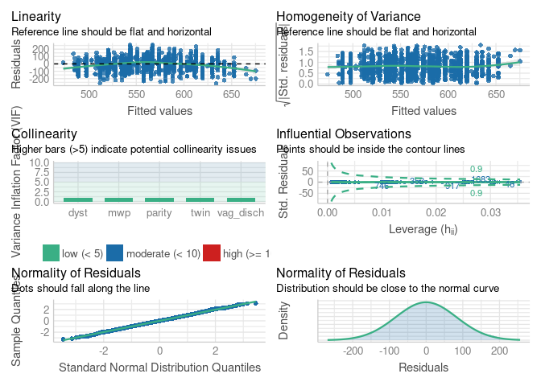

```r
check_model(m_backward2)
```

## Predição com Intervalos de Confiança e de Predição

- Com base nesse modelo ajustado via **Stepwise**, podemos prever a produção de leite nos primeiros 120 dias de latcação de um determinado animal supondo que ele tenha os seguintes características:
1. Já tenha tido duas lactações (**parity = 2**)
2. 45 dias de período de espera até a concepção (**mwp = 45**)
3. Que tenha tido alguma complicação no parto (**dyst = Sim**)
4. Qua não tenha tid0 nascimendo duplo ou gemelar (**twin = Nao**)
5. Que tenha tido corrimento vaginal observado (**vag_disch = Sim**)

```r
# Intervalos de Predição
predict(m_backward, newdata = data.frame(parity = 2, mwp = 45, dyst = "Sim", twin = "Nao",
    vag_disch = "Sim"), interval = "prediction")
```

```
       fit      lwr     upr
1 3232.946 1974.182 4491.71
```

```r
# Intervalos de Confiança
predict(m_backward, newdata = data.frame(parity = 2, mwp = 45, dyst = "Sim", twin = "Nao",
    vag_disch = "Sim"), interval = "confidence")
```

```
       fit      lwr      upr
1 3232.946 3070.279 3395.613
```

## Testando a interação ente as vars *parity* e *dyst*

```r
m_inter <- lm(milk120 ~ parity + dyst + parity * dyst, banco)
summary(m_inter)
```

```
Call:
lm(formula = milk120 ~ parity + dyst + parity * dyst, data = banco)

Residuals:
     Min       1Q   Median       3Q      Max
-1970.32  -437.44   -17.17   422.63  2149.86

Coefficients:
               Estimate Std. Error t value Pr(>|t|)
(Intercept)     2651.91     109.89  24.133  < 2e-16 ***
parity           199.93      43.71   4.574 5.11e-06 ***
dystNao           89.58     115.00   0.779    0.436
parity:dystNao   -30.42      44.90  -0.678    0.498
---
Signif. codes:  0 '***' 0.001 '**' 0.01 '*' 0.05 '.' 0.1 ' ' 1

Residual standard error: 650.7 on 1764 degrees of freedom
Multiple R-squared:  0.1455,    Adjusted R-squared:  0.1441
F-statistic: 100.1 on 3 and 1764 DF,  p-value: < 2.2e-16
```

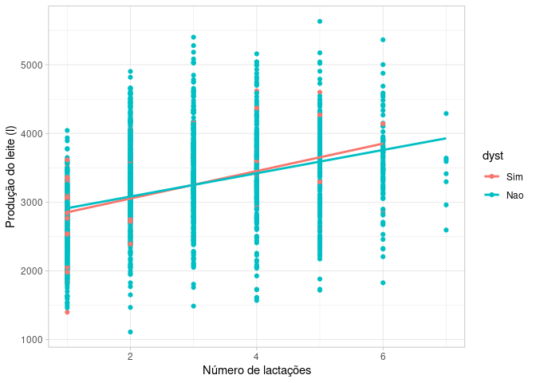

```r
banco %>%
    ggplot(aes(x = parity, y = milk120, color = dyst)) + geom_point() + geom_smooth(method = "lm",
    se = FALSE) + ylab("Produção do leite (l)") + xlab("Número de lactações") +
    theme_light()
```

- Tanto através do modelo ($p-valor = 0.498$) quanto graficamente, observamos que não existem evidências de interação entre ambas variáveis.